# Módulo : Reproducible Resource

Geraldo Barbosa do Amarante

Semana 02 - [Emissão : 26 de novembro de 2017]

## Questão - 01

## LOADING AND PROCESSING THE DATA

1.1 - Load the data.

1.2 - Process/transform the data (if necessary) into a format suitable for your analysis

```r
setwd("D:/coursera/ReproducibleResource/Semana02/ArquivodeDados")
library(readr)
atividade <- read_csv("./activity.csv")
atividadesemNA <- atividade[ with (atividade, { !(is.na(steps)) } ), ]
head(atividadesemNA)
```

```
## # A tibble: 6 x 3
##   steps       date interval
##   <int>     <date>    <int>
## 1     0 2012-10-02        0
## 2     0 2012-10-02        5
## 3     0 2012-10-02       10
## 4     0 2012-10-02       15
## 5     0 2012-10-02       20
## 6     0 2012-10-02       25
```

## Questão - 02

## WHAT IS MEAN TOTALNUMBER OF STEPS TAKEN PER DAY

2.1 - Calculate the total number of steps taken per day

2.2 - If you do not understand the difference between a histogram and a barplot, research the difference between them. Make a histogram of the total number of steps taken each day

2.3 - Calculate and report the mean and median of the total number of steps taken per day

```r
library(dplyr)
agrupamentopordata <- group_by(atividadesemNA, date)
passosdiarios <- summarise(agrupamentopordata, total = sum(steps))
head(agrupamentopordata)
```

```
## # A tibble: 6 x 3
## # Groups:   date [1]
##   steps       date interval
##   <int>     <date>    <int>
## 1     0 2012-10-02        0
## 2     0 2012-10-02        5
## 3     0 2012-10-02       10
## 4     0 2012-10-02       15
## 5     0 2012-10-02       20
## 6     0 2012-10-02       25
```

```r
head(passosdiarios)
```

```
## # A tibble: 6 x 2
##         date total
##       <date> <int>
## 1 2012-10-02   126
## 2 2012-10-03 11352
## 3 2012-10-04 12116
## 4 2012-10-05 13294
## 5 2012-10-06 15420
## 6 2012-10-07 11015
```

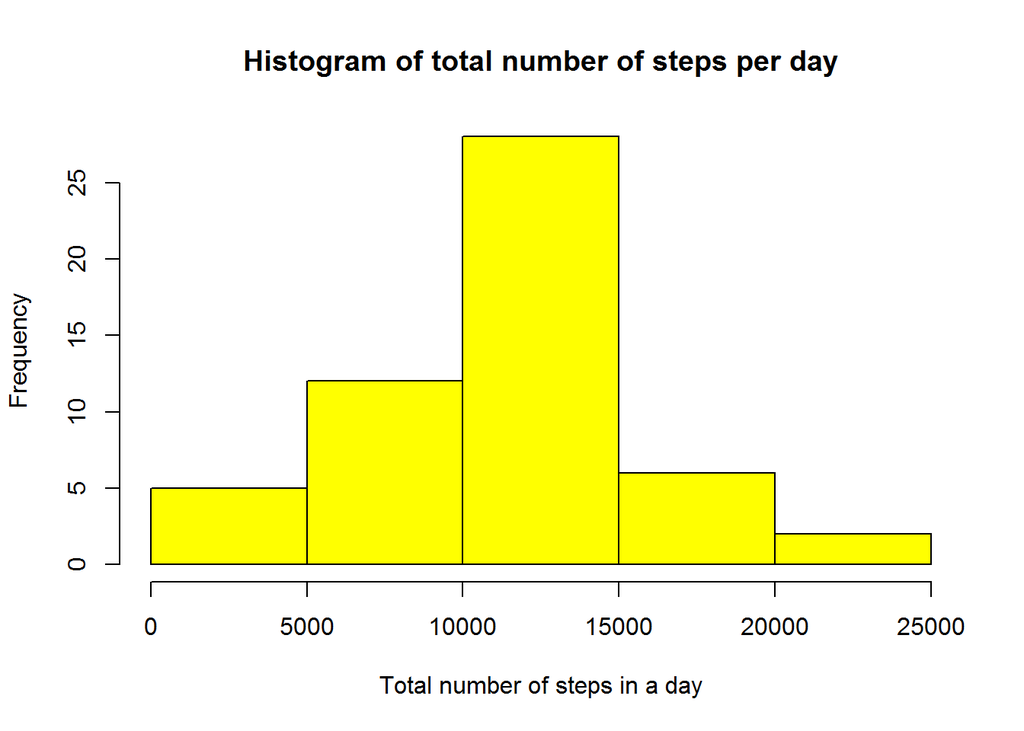

```r
hist(passosdiarios$total, main="Histogram of total number of steps per day",
     xlab="Total number of steps in a day",col = "yellow")
```

```r
summary(passosdiarios)
```

```
##       date                total
##  Min.   :2012-10-02   Min.   :   41
##  1st Qu.:2012-10-16   1st Qu.: 8841
##  Median :2012-10-29   Median :10765
##  Mean   :2012-10-30   Mean   :10766
##  3rd Qu.:2012-11-16   3rd Qu.:13294
##  Max.   :2012-11-29   Max.   :21194
```

## Questão - 03

## WHAT IS THE AVERAGE DAILY ACTIVITY PATTERN?

3.1 - Make a time series plot (i.e. type = “l”) of the 5-minute interval (x-axis) and the average number of steps taken, averaged across all days (y-axis)

3.2 - Which 5-minute interval, on average across all the days in the dataset, contains the maximum number of steps?

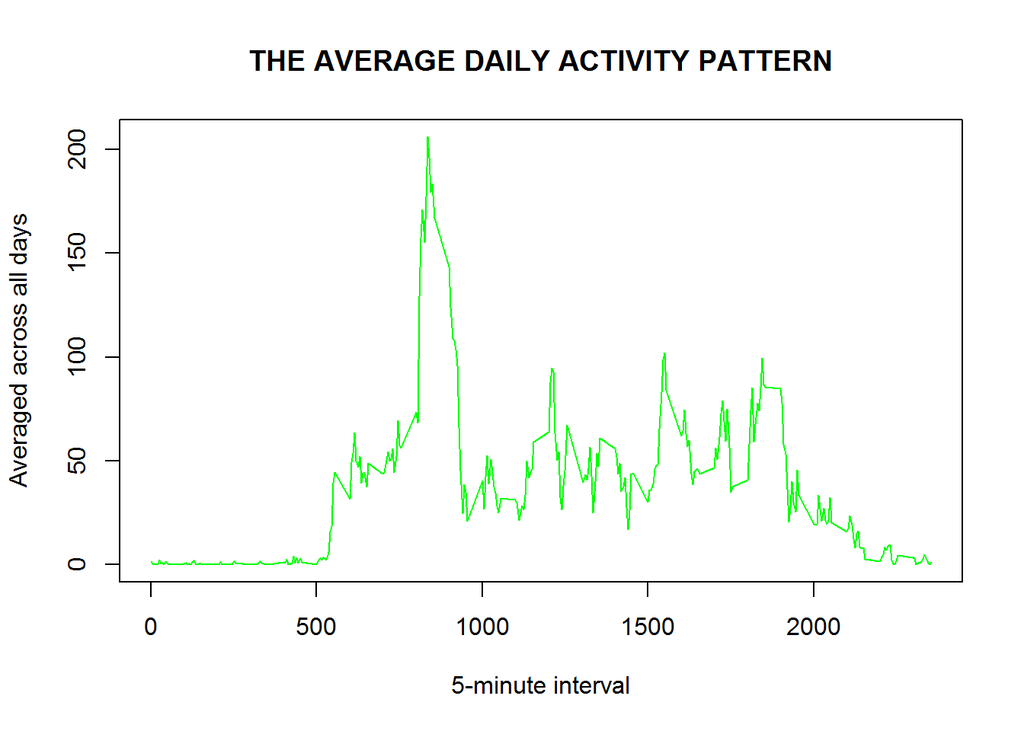

```r
passosporintervalo <- aggregate(steps ~ interval, atividadesemNA, mean)
plot(passosporintervalo$interval, passosporintervalo$steps, type='l',
     main="THE AVERAGE DAILY ACTIVITY PATTERN", xlab="5-minute interval",
     ylab="Averaged across all days",col="green")
```

```r
valoresmaximos <- which.max(passosporintervalo$steps)
passosporintervalo[valoresmaximos, ]
```

```
##     interval    steps
## 104      835 206.1698
```

## Questão - 04

## IMPUTING MISSING VALUES

4.1 - Calculate and report the total number of missing values in the dataset (i.e. the total number of rows with NAs)

4.2 - Devise a strategy for filling in all of the missing values in the dataset. The strategy does not need to be sophisticated. For example, you could use the mean/median for that day, or the mean for that 5-minute interval, etc.

4.3 - Create a new dataset that is equal to the original dataset but with the missing data filled in.

```r
somaatividade <- sum(is.na(atividade))
for (i in 1:nrow(atividade)){
  if (is.na(atividade$steps[i])){
    valorintervalo <- atividade$interval[i]
    registro <- which(passosporintervalo$interval == valorintervalo)
    valorpasso <- passosporintervalo$steps[registro]
    atividade$steps[i] <- valorpasso
  }
}
somaatividade
```

```
## [1] 2304
```

```r
valorintervalo
```

```
## [1] 2355
```

```r
registro
```

```
## [1] 288
```

```r
valorpasso
```

```
## [1] 1.075472
```

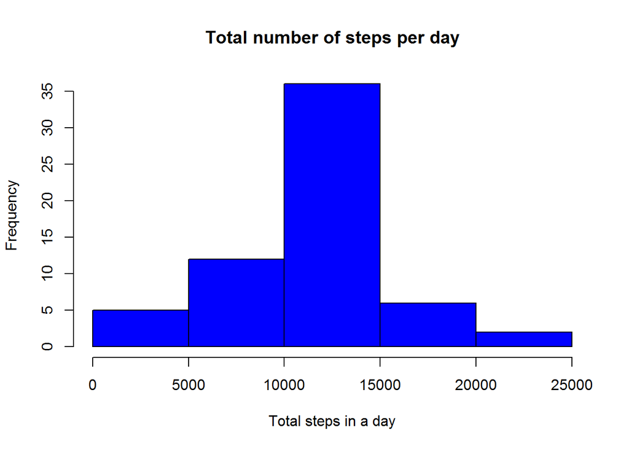

```r
atividadeagregada <- aggregate(steps ~ date, atividade, sum)
atividadeagregadasemNA <- aggregate(steps ~ date, atividadesemNA, sum)
hist(atividadeagregada$steps,main="Total number of steps per day",
     xlab="Total steps in a day", col = "blue")
```

```r
mean(atividadeagregada$steps)
```

```
## [1] 10766.19
```